# Modeling

Hao Zhu

2019-06-24 (updated 2019-09-13)

# Terminology

In the statistical jargon, the final result you want to predict is your outcome/output and the information you will use to generate the prediction is called predictor/input. If your outcome is a categorical variable, you are trying to classify your **new inputs** into different levels. We call this process classification. If your outcome is continuous (basically a number), we will use the regression methods to create the model.

# Getting Started with Modeling

As a language with a 30-year history, the modeling part of R supports several different kinds of inputing format and may confuse some newcomers. Here we are going to introduce you how to state a model with **data** and **formula**, which is the most standard way of making a model in R.

Let’s start with a simple Student’s t-Test. To do that, we have a `t.test` function in R. Such function is called a model function. It creates a specific class of object, which is usually a list to the end, to store every aspect of the model. As we said before, one way of using it is to provide data to this function and provide a fomula you want to use. Formula in R is a special kind of notation and it takes for form of

> y ~ x1 + x2 + …

such that on the left side of `~` sits the outcome variable, while the predictors are on the right side.

```r
t.test(mpg ~ am, data = mtcars)
```

```
##
##  Welch Two Sample t-test
##
## data:  mpg by am
## t = -3.7671, df = 18.332, p-value = 0.001374
## alternative hypothesis: true difference in means is not equal to 0
## 95 percent confidence interval:
##  -11.280194  -3.209684
## sample estimates:
## mean in group 0 mean in group 1
##        17.14737        24.39231
```

Here you can see the T test function gives you the T score (number of standard deviation from mean) and p-value.

# Linear Regression

Following the traditional statistical workflow, after you get results from initial statistical testing (you don’t have to do this step), you can move towards creating some models. If you have continuous outcome and you assume you are going to see a linear relationship in your data, you could use the `lm()` function to create some linear regression model.

```r
fit <- lm(mpg ~ wt, data = mtcars)
fit
```

```
##
## Call:
## lm(formula = mpg ~ wt, data = mtcars)
##
## Coefficients:
## (Intercept)           wt
##      37.285       -5.344
```

The direct results coming from the model only tells us the minimal information. What about the confidence interval or p value? How can we get there?

The fact is that the results from a real model function is an complicated object. In addition, you are expected to use this model in a lot of different ways including doing prediction. All of these actions should not and could not happen at the moment of calculation. Therefore R comes with a lot of functions to facilate these processes. For example you can use `summary()` to summarize a model and use `anova()` to compute analysis of variance.

```r
lm_summary <-summary(fit)
lm_summary
```

```
##
## Call:
## lm(formula = mpg ~ wt, data = mtcars)
##
## Residuals:
##     Min      1Q  Median      3Q     Max
## -4.5432 -2.3647 -0.1252  1.4096  6.8727
##
## Coefficients:
##             Estimate Std. Error t value Pr(>|t|)
## (Intercept)  37.2851     1.8776  19.858  < 2e-16 ***
## wt           -5.3445     0.5591  -9.559 1.29e-10 ***
## ---
## Signif. codes:  0 '***' 0.001 '**' 0.01 '*' 0.05 '.' 0.1 ' ' 1
##
## Residual standard error: 3.046 on 30 degrees of freedom
## Multiple R-squared:  0.7528, Adjusted R-squared:  0.7446
## F-statistic: 91.38 on 1 and 30 DF,  p-value: 1.294e-10
```

The outcome of `summary()` contains many useful insights.

```r
lm_summary$r.squared
```

```
## [1] 0.7528328
```

```r
lm_summary$coefficients
```

```
##              Estimate Std. Error   t value     Pr(>|t|)
## (Intercept) 37.285126   1.877627 19.857575 8.241799e-19
## wt          -5.344472   0.559101 -9.559044 1.293959e-10
```

```r
names(lm_summary)
```

```
##  [1] "call"          "terms"         "residuals"     "coefficients"
##  [5] "aliased"       "sigma"         "df"            "r.squared"
##  [9] "adj.r.squared" "fstatistic"    "cov.unscaled"
```

Another important function to introduce here is this “predict” function, which can be used to predict both confidence interval and prediction interval.

```r
new_cars <- data.frame(
  wt = c(1.256, 2.378),
  hp = c(100, 200)
)

# Predict confidence interval
predict(fit, new_cars, interval = "confidence")
```

```
##        fit      lwr      upr
## 1 30.57247 28.07763 33.06731
## 2 24.57597 23.11737 26.03458
```

```r
# Predict prediction interval
predict(fit, new_cars, interval = "prediction")
```

```
##        fit      lwr      upr
## 1 30.57247 23.87030 37.27464
## 2 24.57597 18.18673 30.96521
```

However, here comes the problem. As you can imagine we have a lot of different kinds of models in R. We want to have a standardized workflow and use the same functions on different models. It means that functions like `summary()` needs to be able to react differently for different models. This is called “methods” in R.

For these types of functions, if you need to search for help, you need to search for things like `summary.lm`. That is the actual help file you should look at. The documentation of `summary` usually won’t give you what you need.

Let’s get back to modeling. Base R `summary()` is great but the output generated is not in a table format. This worked well when analysts would transcribe the results by hand into a table, but it is not very conducive to using R Markdown and generaing automated reports. Therefore, deeply influenced by the `tidyverse` package, the `broom` package includes tools to extract the information from models into a table. A lot of effort has been understaken in order to standardize all statistical models into the same format.

```r
library(broom)

tidy(fit, conf.int = T)
```

```
## # A tibble: 2 x 7
##   term        estimate std.error statistic  p.value conf.low conf.high
##   <chr>          <dbl>     <dbl>     <dbl>    <dbl>    <dbl>     <dbl>
## 1 (Intercept)    37.3      1.88      19.9  8.24e-19    33.5      41.1
## 2 wt             -5.34     0.559     -9.56 1.29e-10    -6.49     -4.20
```

`broom` also comes with 2 other verbs: `glance()` and `augment()`. The former provides a table summary of goodness of fit measures. The latter provides information on how individual data points contribute to the model.

```r
glance(fit)
```

```
## # A tibble: 1 x 11
##   r.squared adj.r.squared sigma statistic  p.value    df logLik   AIC   BIC
##       <dbl>         <dbl> <dbl>     <dbl>    <dbl> <int>  <dbl> <dbl> <dbl>
## 1     0.753         0.745  3.05      91.4 1.29e-10     2  -80.0  166.  170.
## # … with 2 more variables: deviance <dbl>, df.residual <int>
```

```r
augment(fit)
```

```
## # A tibble: 32 x 10
##    .rownames   mpg    wt .fitted .se.fit .resid   .hat .sigma .cooksd
##    <chr>     <dbl> <dbl>   <dbl>   <dbl>  <dbl>  <dbl>  <dbl>   <dbl>
##  1 Mazda RX4  21    2.62    23.3   0.634 -2.28  0.0433   3.07 1.33e-2
##  2 Mazda RX…  21    2.88    21.9   0.571 -0.920 0.0352   3.09 1.72e-3
##  3 Datsun 7…  22.8  2.32    24.9   0.736 -2.09  0.0584   3.07 1.54e-2
##  4 Hornet 4…  21.4  3.22    20.1   0.538  1.30  0.0313   3.09 3.02e-3
##  5 Hornet S…  18.7  3.44    18.9   0.553 -0.200 0.0329   3.10 7.60e-5
##  6 Valiant    18.1  3.46    18.8   0.555 -0.693 0.0332   3.10 9.21e-4
##  7 Duster 3…  14.3  3.57    18.2   0.573 -3.91  0.0354   3.01 3.13e-2
##  8 Merc 240D  24.4  3.19    20.2   0.539  4.16  0.0313   3.00 3.11e-2
##  9 Merc 230   22.8  3.15    20.5   0.540  2.35  0.0314   3.07 9.96e-3
## 10 Merc 280   19.2  3.44    18.9   0.553  0.300 0.0329   3.10 1.71e-4
## # … with 22 more rows, and 1 more variable: .std.resid <dbl>
```

# Model Construction Pipeline

## Running multiple models in one pipe

The `purrr` package in `tidyverse` is very useful when you want to run multiple models in one run. It was originally provided as a standardized tool to perform vectorized operations in R, which covers vectors and lists.

```r
library(tidyverse)
mtcars_purrr <- mtcars %>%
  gather("key", "value", -mpg) %>%
  group_nest(key) %>%
  mutate(
    data = map(data, ~broom::tidy(lm(mpg ~ value, data = .x), conf.int = T))
  ) %>%
  unnest()

mtcars_purrr
```

```
## # A tibble: 20 x 8
##    key   term      estimate std.error statistic  p.value conf.low conf.high
##    <chr> <chr>        <dbl>     <dbl>     <dbl>    <dbl>    <dbl>     <dbl>
##  1 am    (Interce…  17.1      1.12       15.2   1.13e-15  14.9      19.4
##  2 am    value       7.24     1.76        4.11  2.85e- 4   3.64     10.8
##  3 carb  (Interce…  25.9      1.84       14.1   9.22e-15  22.1      29.6
##  4 carb  value      -2.06     0.569      -3.62  1.08e- 3  -3.22     -0.895
##  5 cyl   (Interce…  37.9      2.07       18.3   8.37e-18  33.6      42.1
##  6 cyl   value      -2.88     0.322      -8.92  6.11e-10  -3.53     -2.22
##  7 disp  (Interce…  29.6      1.23       24.1   3.58e-21  27.1      32.1
##  8 disp  value      -0.0412   0.00471    -8.75  9.38e-10  -0.0508   -0.0316
##  9 drat  (Interce…  -7.52     5.48       -1.37  1.80e- 1 -18.7       3.66
## 10 drat  value       7.68     1.51        5.10  1.78e- 5   4.60     10.8
## 11 gear  (Interce…   5.62     4.92        1.14  2.62e- 1  -4.42     15.7
## 12 gear  value       3.92     1.31        3.00  5.40e- 3   1.25      6.59
## 13 hp    (Interce…  30.1      1.63       18.4   6.64e-18  26.8      33.4
## 14 hp    value      -0.0682   0.0101     -6.74  1.79e- 7  -0.0889   -0.0476
## 15 qsec  (Interce…  -5.11    10.0        -0.510 6.14e- 1 -25.6      15.4
## 16 qsec  value       1.41     0.559       2.53  1.71e- 2   0.270     2.55
## 17 vs    (Interce…  16.6      1.08       15.4   8.85e-16  14.4      18.8
## 18 vs    value       7.94     1.63        4.86  3.42e- 5   4.61     11.3
## 19 wt    (Interce…  37.3      1.88       19.9   8.24e-19  33.5      41.1
## 20 wt    value      -5.34     0.559      -9.56  1.29e-10  -6.49     -4.20
```

## Imputation

When you have missing values in your data, imputation allows you to replace the missing values with estimates based on the available data, and reduce potential bias created by deleting missing observations.

There are a number of different imputation strategies. Basic ones include mean/mode/median imputation. KNN can also be used to perform nearest neighbors imputation.

```r
mtcars_mis <- mtcars
mtcars_mis$wt[sample(nrow(mtcars), 6)] <- NA
mtcars_mis$hp[sample(nrow(mtcars), 6)] <- NA

sum(is.na(mtcars_mis$wt))
```

```
## [1] 6
```

For this kind of simple imputation, the recipes might be able to speed up the process a lot. The `recipes` package uses the `tidyverse` selector and helps you to build a “formula” of processing the data. Such formula includes common practices such as imputation and standardization. You don’t have to use this package but it helps.

```r
library(recipes)
recipe(mpg ~ wt + hp, data = mtcars_mis) %>%
  step_meanimpute(all_predictors()) %>%
  prep() %>%
  juice()
```

```
## # A tibble: 32 x 3
##       wt    hp   mpg
##    <dbl> <dbl> <dbl>
##  1  2.62  143.  21
##  2  2.88  110   21
##  3  2.32   93   22.8
##  4  3.22  110   21.4
##  5  3.44  143.  18.7
##  6  3.46  105   18.1
##  7  3.33  245   14.3
##  8  3.19   62   24.4
##  9  3.15   95   22.8
## 10  3.44  143.  19.2
## # … with 22 more rows
```

You can also perform multiple imputation (MI) via the [`mice`](https://github.com/stefvanbuuren/mice) package.

```r
library(mice)
# you can specify the number of multiple imputations using m.
imputed_mtcars <- mice(mtcars_mis, m = 6, method = "pmm")
# and call out the 1st set of imputation in complete.
mice::complete(imputed_mtcars, 1)
```

```
##     mpg cyl  disp  hp drat    wt  qsec vs am gear carb
## 1  21.0   6 160.0 180 3.90 2.620 16.46  0  1    4    4
## 2  21.0   6 160.0 110 3.90 2.875 17.02  0  1    4    4
## 3  22.8   4 108.0  93 3.85 2.320 18.61  1  1    4    1
## 4  21.4   6 258.0 110 3.08 3.215 19.44  1  0    3    1
## 5  18.7   8 360.0 150 3.15 3.440 17.02  0  0    3    2
## 6  18.1   6 225.0 105 2.76 3.460 20.22  1  0    3    1
## 7  14.3   8 360.0 245 3.21 3.845 15.84  0  0    3    4
## 8  24.4   4 146.7  62 3.69 3.190 20.00  1  0    4    2
## 9  22.8   4 140.8  95 3.92 3.150 22.90  1  0    4    2
## 10 19.2   6 167.6 150 3.92 3.440 18.30  1  0    4    4
## 11 17.8   6 167.6 123 3.92 3.440 18.90  1  0    4    4
## 12 16.4   8 275.8 180 3.07 4.070 17.40  0  0    3    3
## 13 17.3   8 275.8 180 3.07 3.730 17.60  0  0    3    3
## 14 15.2   8 275.8 180 3.07 3.780 18.00  0  0    3    3
```

[output cut: 18 more lines]

You can use the `purrr` skills you just learned to construct a separate model for each imputed dataset.

```r
map(1:6, ~ mice::complete(imputed_mtcars, .x)) %>%
  map_df(~ broom::tidy(lm(mpg ~ wt + hp, data = .x)))
```

```
## # A tibble: 18 x 5
##    term        estimate std.error statistic  p.value
##    <chr>          <dbl>     <dbl>     <dbl>    <dbl>
##  1 (Intercept)  37.5      1.62        23.2  2.92e-20
##  2 wt           -3.76     0.620       -6.06 1.34e- 6
##  3 hp           -0.0349   0.00874     -4.00 4.05e- 4
##  4 (Intercept)  37.9      1.58        24.0  1.12e-20
##  5 wt           -4.24     0.606       -7.01 1.05e- 7
##  6 hp           -0.0279   0.00867     -3.23 3.11e- 3
##  7 (Intercept)  36.4      1.97        18.5  1.40e-17
##  8 wt           -4.00     0.813       -4.92 3.16e- 5
##  9 hp           -0.0232   0.0117      -1.99 5.66e- 2
## 10 (Intercept)  36.5      1.72        21.1  3.62e-19
## 11 wt           -3.30     0.676       -4.88 3.55e- 5
## 12 hp           -0.0363   0.0100      -3.62 1.12e- 3
## 13 (Intercept)  37.8      1.47        25.7  1.73e-21
## 14 wt           -4.34     0.564       -7.69 1.78e- 8
## 15 hp           -0.0236   0.00753     -3.13 3.93e- 3
## 16 (Intercept)  37.8      1.51        25.0  3.74e-21
## 17 wt           -4.02     0.548       -7.34 4.36e- 8
## 18 hp           -0.0303   0.00712     -4.26 1.97e- 4
```

## Standardization

Sometimes we have predictors at totally different scales, it might be a good idea to standardize the values before sending them directly into the model. In this way, we can make sure different factors can be weighted on the same level when the model gets constructed. Again, the `recipes` package can be very helpful here.

```r
scale_recipe <- recipe(mpg ~ wt + hp, data = mtcars) %>%
  step_center(all_predictors()) %>%
  step_scale(all_predictors()) %>%
  prep()

juice(scale_recipe)
```

```
## # A tibble: 32 x 3
##          wt     hp   mpg
##       <dbl>  <dbl> <dbl>
##  1 -0.610   -0.535  21
##  2 -0.350   -0.535  21
##  3 -0.917   -0.783  22.8
##  4 -0.00230 -0.535  21.4
##  5  0.228    0.413  18.7
##  6  0.248   -0.608  18.1
##  7  0.361    1.43   14.3
##  8 -0.0278  -1.24   24.4
##  9 -0.0687  -0.754  22.8
## 10  0.228   -0.345  19.2
## # … with 22 more rows
```

## Visualization

The most common techinique for visualizing models are forest plots, which are basically rotated point-and-error-bar plots. Here, we will use the data from the multiple univariate `lm()` models we created in the `purrr` example above.

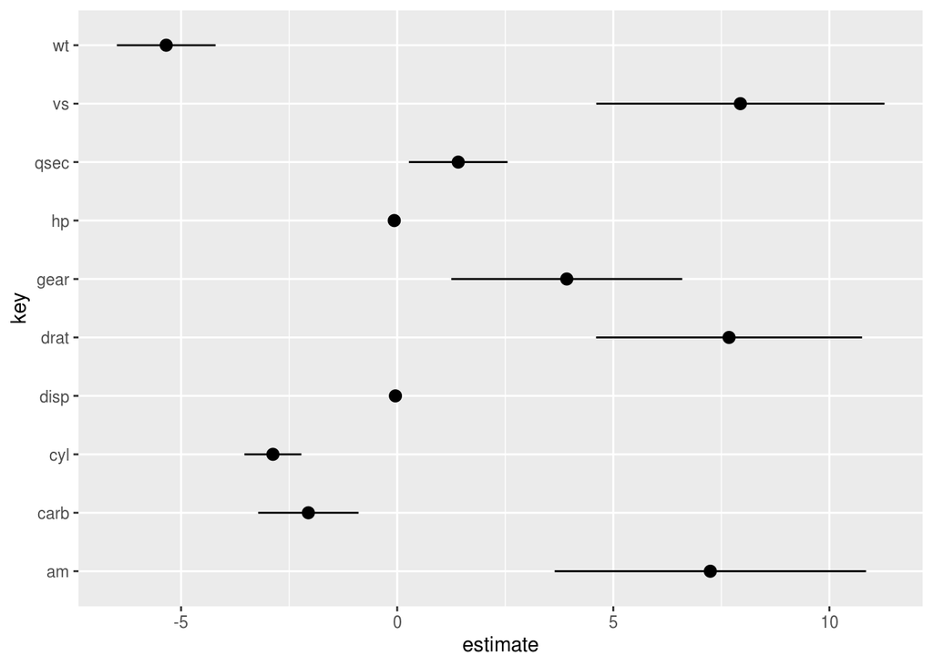

```r
mtcars_purrr %>%
  # remove all the "intercept" items and keep only those slopes.
  filter(term == "value") %>%
  ggplot(aes(x = key, y = estimate, ymin = conf.low, ymax = conf.high)) +
  geom_pointrange() +
  coord_flip()
```

# Common Statistical models

## GLM

### linear regression

```r
glm_fit <- glm(mpg ~ wt + hp, data = mtcars)
broom::tidy(glm_fit)
```

```
## # A tibble: 3 x 5
##   term        estimate std.error statistic  p.value
##   <chr>          <dbl>     <dbl>     <dbl>    <dbl>
## 1 (Intercept)  37.2      1.60        23.3  2.57e-20
## 2 wt           -3.88     0.633       -6.13 1.12e- 6
## 3 hp           -0.0318   0.00903     -3.52 1.45e- 3
```

### Binomial logistic regression

Note that for logistical and multinomial models, you need to exponentiate the beta coefficients to get the odds ratios. If you are using base R’s summaryfunction, you need to run `exp()` by yourself. If you are using `broom::tidy()`, you need to put `exponentiate = T` in your `tidy` function. A typical rule of thumb is that if you use `log` or `logit` in your link function (for example, here the `binomial(link = "logit")` is our link function), then you need to exponentiate your coefficient.

```r
glm_bino <- glm(vs ~ wt + hp, data = mtcars, family = binomial(link = "logit"))

tidy(glm_bino, exponentiate = T)
```

```
## # A tibble: 3 x 5
##   term        estimate std.error statistic p.value
##   <chr>          <dbl>     <dbl>     <dbl>   <dbl>
## 1 (Intercept) 1653.       3.43       2.16   0.0307
## 2 wt             2.73     1.23       0.815  0.415
## 3 hp             0.918    0.0360    -2.37   0.0178
```

### Poisson logistic regression

Running Poisson logistic regression is very similiar to binomial logistic regression.

```r
poisson_dt <- data.frame(
  count = sample(100, 10),
  a = rnorm(10),
  b = rnorm(10)
)
poisson_glm <- glm(count ~ a + b, data = poisson_dt, family = poisson(link = "log"))

tidy(poisson_glm, exponentiate = T, conf.int = T)
```

```
## # A tibble: 3 x 7
##   term        estimate std.error statistic    p.value conf.low conf.high
##   <chr>          <dbl>     <dbl>     <dbl>      <dbl>    <dbl>     <dbl>
## 1 (Intercept)    47.4     0.0584     66.1  0             42.1      53.0
## 2 a               1.23    0.0524      3.98 0.0000681      1.11      1.37
## 3 b               1.37    0.0705      4.42 0.00000998     1.19      1.57
```

## Mixed Effect

For all mixed effect models, we can use the `lme()` function from `library(nlme)`

```r
library(nlme)

exer <- read_csv("https://stats.idre.ucla.edu/stat/data/exer.csv")
exer <- exer %>%
  mutate(
    id = factor(id),
    diet = factor(diet),
    exertype = factor(exertype),
    time = factor(time)
  )

head(exer)
```

```
## # A tibble: 6 x 5
##   id    diet  exertype pulse time
##   <fct> <fct> <fct>    <dbl> <fct>
## 1 1     1     1           85 1
## 2 1     1     1           85 2
## 3 1     1     1           88 3
## 4 2     1     1           90 1
## 5 2     1     1           92 2
## 6 2     1     1           93 3
```

```r
mixed_effect_fit <- lme(
  pulse ~ diet + exertype,
  random = ~ 1 | id / time,
  data = exer
)

summary(mixed_effect_fit)
```

```
## Linear mixed-effects model fit by REML
##  Data: exer
##        AIC     BIC    logLik
##   680.9126 698.093 -333.4563
##
## Random effects:
##  Formula: ~1 | id
##         (Intercept)
## StdDev:  0.00147486
##
##  Formula: ~1 | time %in% id
##         (Intercept)   Residual
## StdDev:    10.81578 0.08170659
##
## Fixed effects: pulse ~ diet + exertype
##                Value Std.Error DF  t-value p-value
## (Intercept) 87.08889  2.280232 60 38.19299  0.0000
## diet2        7.48889  2.280232 26  3.28427  0.0029
## exertype2    4.36667  2.792703 26  1.56360  0.1300
## exertype3   22.23333  2.792703 26  7.96122  0.0000
##  Correlation:
##           (Intr) diet2  exrty2
## diet2     -0.500
## exertype2 -0.612  0.000
## exertype3 -0.612  0.000  0.500
##
## Standardized Within-Group Residuals:
##           Min            Q1           Med            Q3           Max
## -0.0159317231 -0.0047861129  0.0005548556  0.0035056773  0.0231797643
##
## Number of Observations: 90
## Number of Groups:
##           id time %in% id
##           30           90
```

## Survival Analysis

You can learn more about survival analysis in R from this blog post: https://rviews.rstudio.com/2017/09/25/survival-analysis-with-r/. In addition to what mentioned in this post, the [survminer](https://cran.r-project.org/web/packages/survminer/vignettes/Informative_Survival_Plots.html) package is another great tool to use for survival analysis.